# Supp Code D : RNAseq analysis and MOFA

21/11/2019

This code includes details for pre-processing and filtering data to be used with the MOFA package: 1. Mean-adjusting flow cytometry data 2. RNA-seq library size normalisation and then VSN. 3. selecting the top 5000 most variable genes

For more information on MOFA: Ricard Argelaguet, Britta Velten, Damien Arnol, Florian Buettner, Wolfgang Huber and Oliver Stegle (2019). MOFA: Multi-Omics Factor Analysis (MOFA). R package version 1.0.0. https://bioconductor.org/packages/devel/bioc/html/MOFA.html

** NOTE: Code chunks 3 and 4 are provided for reference only - their outputs required for all downstream elements for running MOFA are provided in the RData file **

Included in the RData file are the following variables, lists and dataframes: “annot” : dataframe with sample details of sequenced samples. “for.MOFA” : untransformed flow data (% of parent population) “t.MOFA.parent” : dataframe with transformed celltype frequencies as row, samples as columns “vsd.filtered” : matrix with vsn normalised read counts as rows, samples as columns “BTM” <- Blood Transcriptional module gene sets. for gmt file access original paper https://doi.org/10.1038/ni.2789 “counts” : Raw counts file post Rsubread “list.for.MOFA” : List containing flow and rna-seq data after processing “MOFAobject” : Post-MOFA run file containing the optimal MOFA model used in this study.

# Load packages and data

NOTE: MOFA is a bioconductor package. To install use the following chunk.

```r
install.packages("BiocManager")
BiocManager::install("MOFA", pkgType = "source") # the usage of packrat means a pre-compiled installation can fail, so specifying 'source' is prudent.
BiocManager::install("MOFAdata", pkgType = "source") # the usage of packrat means a pre-compiled installation can fail, so specifying 'source' is prudent.
```

```r
# library(Rsubread) # only use if quantifying RNA-seq from scratch
# library(DESeq2) # only use if quantifying RNA-seq from scratch
# library(org.Hs.eg.db) # only use if quantifying RNA-seq from scratch
library(MOFA)
```

```r
library(MOFAdata)
library(ggplot2)
library(qusage)
library(reticulate)
use_condaenv("miniconda2", conda = "~/opt/miniconda2/bin/conda",required = T) # this assumes you have installed mofapy via miniconda2 to your 'base' environment.

load("data/Supp_code_D_RNAseq_analysis.RData") # modify for local machine directory
```

# SAMPLE SELECTION Flow data: normalise cell frequencies using whole cohort and “% of parent population” data (FOR REFERENCE ONLY)

```r
norm.MOFA <- for.MOFA #only cell type data

conf.Int <- matrix(nrow = 61, ncol =6) #initiate matrix
#normalise data - using the mean calculated from the 5-95th percentile of data
for(i in 1:61){
  conf.Int[i,1] <- quantile(norm.MOFA[,i], probs=c(0.05), na.rm= T)
  conf.Int[i,2] <- quantile(norm.MOFA[,i], probs=c(0.95), na.rm= T)
  conf.Int[i,3] <-  mean(norm.MOFA[((norm.MOFA[,i] > conf.Int[i,1]) & (norm.MOFA[,i] < conf.Int[i,2])),i], na.rm= T)
  conf.Int[i,4] <-  sd(norm.MOFA[((norm.MOFA[,i] > conf.Int[i,1]) & (norm.MOFA[,i] < conf.Int[i,2])),i], na.rm= T)
  conf.Int[i,5] <- mad(norm.MOFA[,i], na.rm = T, low = FALSE, high = FALSE)
  conf.Int[i,6] <- median(norm.MOFA[,i], na.rm = T, low = FALSE, high = FALSE)
}

#### Mean adjusted z-score
for(i in 1:61){
  norm.MOFA[,i] <- (norm.MOFA[,i] - conf.Int[i,3])/(conf.Int[i,4])
}

#select out data to match the sequencing data:
month0keep <- c(2750,2856,2758,2982,2849,2989,2895,2936,2893,2876,2880,2873,2708,2898,3044,2776,2718,2764,2852,2715,3085)
MOFA.M0 <- norm.MOFA[norm.MOFA$PID %in% month0keep & norm.MOFA$study.bleed %in% "M0",]
MOFA.M0$PID <- paste(MOFA.M0$PID,"_M0", sep = "") ## add annotation

month32keep <- c(2817,2826,2863,2895,2965,2758,2943,2893,3025)
MOFA.M32 <- norm.MOFA[norm.MOFA$PID %in% month32keep & norm.MOFA$study.bleed %in% "M32",]
MOFA.M32$PID <- paste(MOFA.M32$PID,"_M32", sep = "") ## add annotation

# build dataset for MOFA
MOFA <- rbind(MOFA.M0,MOFA.M32)
rownames(MOFA) <- MOFA$PID # convert PID to rownames
MOFA <- MOFA[order(MOFA$PID),]
MOFA <- MOFA[,1:61] # remove additional columns column
t.MOFA.parent <-  as.data.frame(t(MOFA)) #transpose so that cell types are row, and samples are columns.
                                        # t.MOFA.parent is now ready for use in MOFA
```

# SAMPLE selection : Sequencing data (FOR REFERENCE ONLY).

```r
#example code to generate vsn normalised data, this is provided in the Rdata file
# select files: change the 'path' part to adjust to different samples. Access the raw data for this paper via GEO
# We align with hisat2 and return bam files:

# fls <- list.files(path = "/XXXX",pattern = 'hisat2.bam$',full.names = T)

#### Read counting
## the code below can be used to generate "counts", which is included in the Rdata file
counts <- featureCounts(files = fls,
                        # Change the genome if aligned to others:
                        annot.ext = "/bi/scratch/Genomes/Human/GRCh38_ERCC/Homo_sapiens.GRCh38.87.gtf",
                        # Metafeatures = T counts at gene level:
                        isGTFAnnotationFile = T, useMetaFeatures = T, nthreads = 7 )

#### perform variance stabilisation
dds <- DESeqDataSetFromMatrix(countData = counts$counts, colData = annot, ~ study.bleed)
vsd <- varianceStabilizingTransformation(dds, blind = F)

### Order by gene variance
rowVarFilter <- function(x,ntop){
  rowvars <- apply(assay(x),1,var)
  rowvars <- rowvars[order(rowvars, decreasing = T)]
  genes.of.interest <- rowvars[1:ntop]
  x <- x[names(genes.of.interest),]
  return(x)
}

vsd.filtered <-rowVarFilter(vsd,58051)
# as a matrix
vsd.filtered.matrix <- assay(vsd.filtered)
colnames(vsd.filtered.matrix) <- vsd.filtered$PID
vsd.filtered.matrix <- vsd.filtered.matrix[,order(vsd.filtered$PID)]

# ##add gene symbols
symbol <- as.character(mapIds(org.Hs.eg.db,
                          keys=row.names(vsd.filtered.matrix),
                             column="SYMBOL",
                             keytype="ENSEMBL",
                             multiVals="first"))

## remove any EMSEMBL IDs without gene symbols.
## This is needed to match the blood transcriptional module gene sets used for downstream analysis
rownames(vsd.filtered.matrix) <-symbol
vsd.filtered.matrix <- vsd.filtered.matrix[!is.na(rownames(vsd.filtered.matrix)),]
vsd.filtered.matrix <- vsd.filtered.matrix[!duplicated(rownames(vsd.filtered.matrix)),]
vsd.filtered.matrix <- vsd.filtered.matrix[,order(colnames(vsd.filtered.matrix))]

rowVarFilter2 <- function(x,ntop){
  rowvars <- apply(x,1,var)
  rowvars <- rowvars[order(rowvars, decreasing = T)]
  genes.of.interest <- rowvars[1:ntop]
  x <- x[names(genes.of.interest),]

  return(x)
}
vsd.filtered.matrix <-rowVarFilter2(vsd.filtered.matrix,5000) # filter for the 5000 most variable genes

##idiot check that columns are correctly ordered:
colnames(vsd.filtered.matrix) == colnames(t.MOFA.parent)
```

#Build MOFA object

```r
# This script outlines how to structure and run MOFA model. However the "MOFAobject" included in the RData file is final model used in this manuscript.

# Create MOFA object
list.for.MOFA.parent <- list("rnaseq"=as.matrix(vsd.filtered.matrix),"flow"=as.matrix(t.MOFA.parent))
MOFAobject <- createMOFAobject(list.for.MOFA.parent)
```

```
## Creating MOFA object from a list of matrices
##  please make sure that samples are stored in the columns and features in the rows...
```

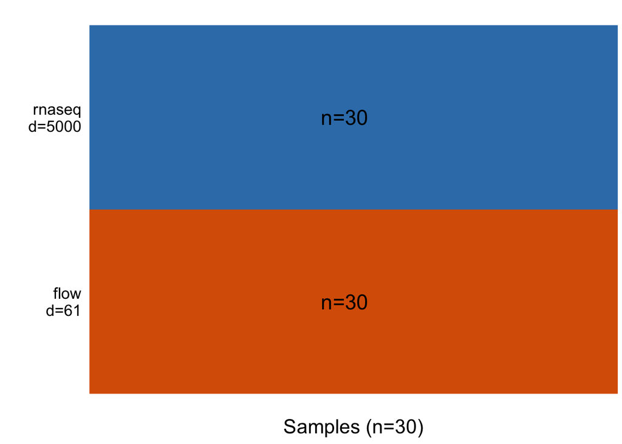

```r
plotDataOverview(MOFAobject)
```

```r
DataOptions <- getDefaultDataOptions()

##Define model options
ModelOptions <- getDefaultModelOptions(MOFAobject)
ModelOptions$numFactors <- 25
ModelOptions
```

```
## $likelihood
##     rnaseq       flow
## "gaussian" "gaussian"
##
## $numFactors
## [1] 25
##
## $sparsity
## [1] TRUE
```

```r
TrainOptions <- getDefaultTrainOptions()
TrainOptions$DropFactorThreshold <- 0.02 # Automatically drop factors that explain less than 2% of variance in all omics

###  Prepare MOFA models x10 and select the model with best fit
n_inits <- 10
MOFAlist <- lapply(seq_len(n_inits), function(it) {
    TrainOptions$seed <- 2019 + it
    MOFAobject <- prepareMOFA(
    MOFAobject,
    DataOptions = DataOptions,
    ModelOptions = ModelOptions,
    TrainOptions = TrainOptions
  )
    runMOFA(MOFAobject)
})
```

```
## Checking data options...
```

```
## Checking training options...
```

```
## Checking model options...
```

```
## [1] "No output file provided, using a temporary file..."
```

```
## Such (strong) factors usually appear when count-based assays are not properly normalised by library size.
```

```
## Checking data options...
```

```
## Checking training options...
```

```
## Checking model options...
```

```
## [1] "No output file provided, using a temporary file..."
```

```
## Such (strong) factors usually appear when count-based assays are not properly normalised by library size.
```

```
## Checking data options...
```

```
## Checking training options...
```

```
## Checking model options...
```

```
## [1] "No output file provided, using a temporary file..."
```

```
## Checking data options...
```

```
## Checking training options...
```

```
## Checking model options...
```

```
## [1] "No output file provided, using a temporary file..."
```

```
## Such (strong) factors usually appear when count-based assays are not properly normalised by library size.
```

```
## Checking data options...
```

```
## Checking training options...
```

```
## Checking model options...
```

```
## [1] "No output file provided, using a temporary file..."
```

```
## Such (strong) factors usually appear when count-based assays are not properly normalised by library size.
```

```
## Checking data options...
```

```
## Checking training options...
```

```
## Checking model options...
```

```
## [1] "No output file provided, using a temporary file..."
```

```
## Such (strong) factors usually appear when count-based assays are not properly normalised by library size.
```

```
## Checking data options...
```

```
## Checking training options...
```

```
## Checking model options...
```

```
## [1] "No output file provided, using a temporary file..."
```

```
## Checking data options...
```

```
## Checking training options...
```

```
## Checking model options...
```

```
## [1] "No output file provided, using a temporary file..."
```

```
## Checking data options...
```

```
## Checking training options...
```

```
## Checking model options...
```

```
## [1] "No output file provided, using a temporary file..."
```

```
## Checking data options...
```

```
## Checking training options...
```

```
## Checking model options...
```

```
## [1] "No output file provided, using a temporary file..."
```

```
## Such (strong) factors usually appear when count-based assays are not properly normalised by library size.
```

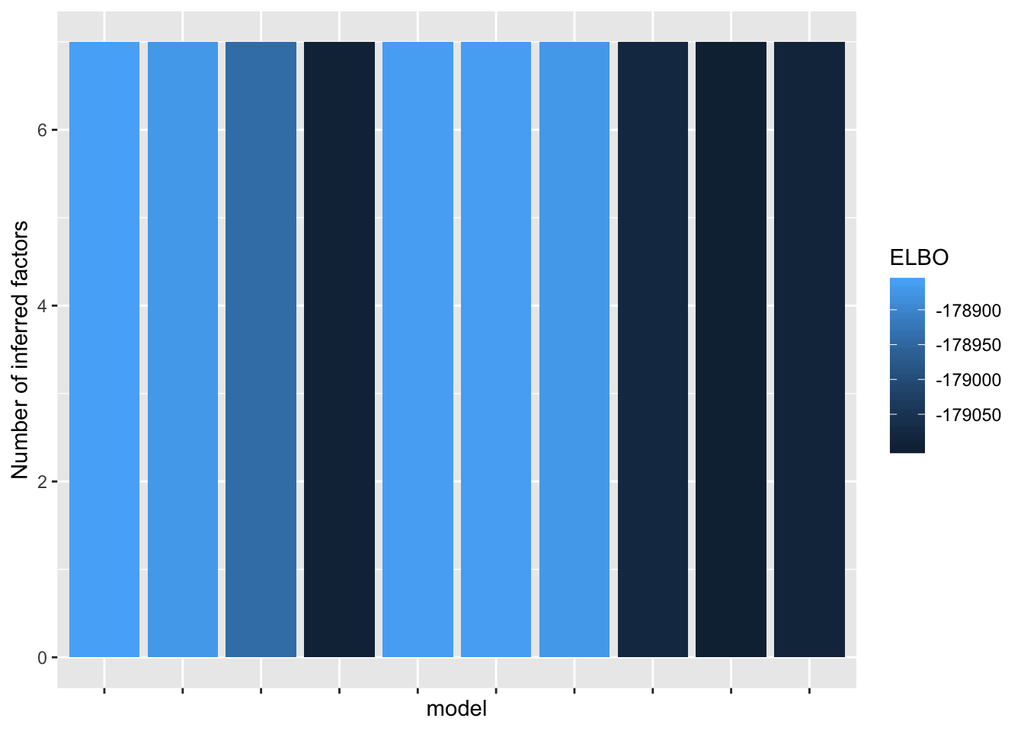

```r
compareModels(MOFAlist)
```

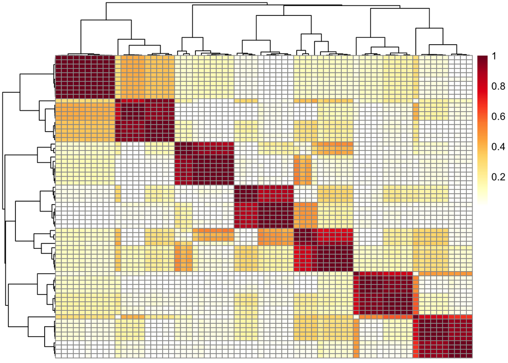

```r
compareFactors(MOFAlist)
```

```r
MOFAobject <- MOFA::selectModel(MOFAlist, plotit = FALSE)   # final MOFAmodel

r2 <- calculateVarianceExplained(MOFAobject)
r2$R2Total
```

```
##      flow    rnaseq
## 0.4033306 0.6408967
```

```r
head(r2$R2PerFactor) # Variance explained by each factor in each view
```

```
##             flow     rnaseq
## LF1 0.0844395277 0.17750209
## LF2 0.0003292057 0.18486227
## LF3 0.1169893665 0.04382460
## LF4 0.0477713002 0.11227135
## LF5 0.1025303401 0.02515543
## LF6 0.0244535666 0.07768663
```

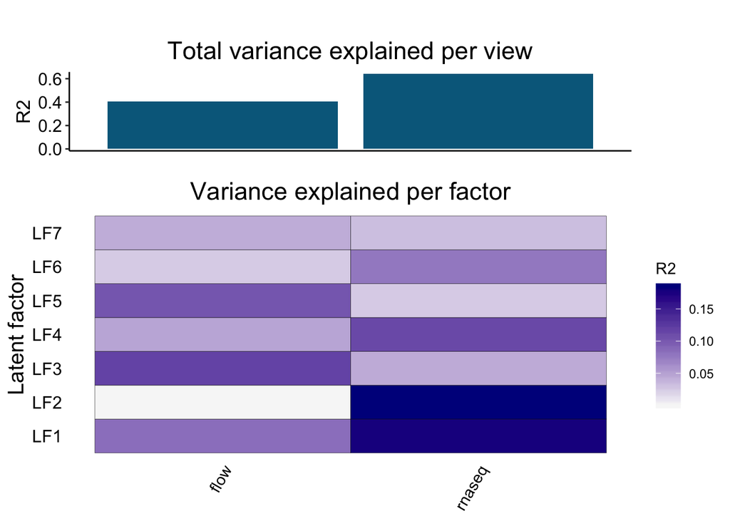

```r
plotVarianceExplained(MOFAobject)
```

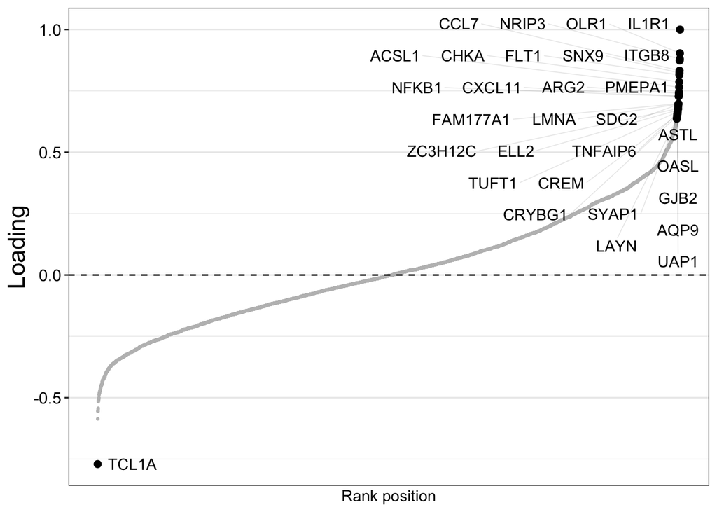

```r
## investigate the factors for genes and cell types. Change factor from to "2" to investigate the second factor
plotWeights(
  MOFAobject,
  view = "rnaseq",
  factor = 1,
  nfeatures = 30
)
```

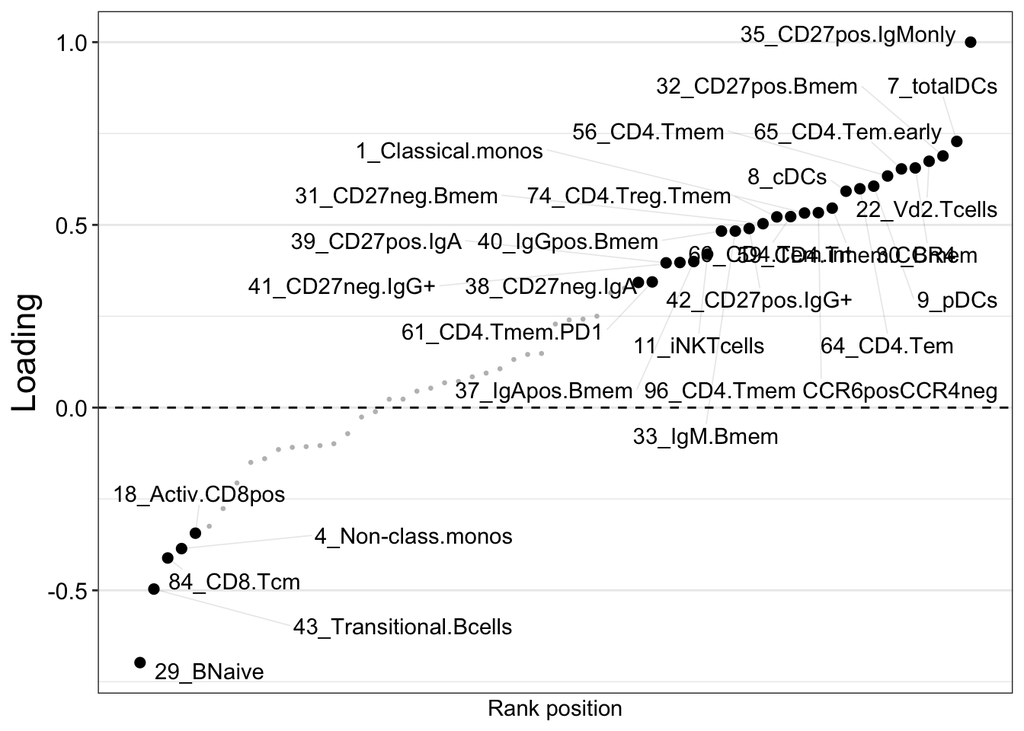

```r
plotWeights(
  MOFAobject,
  view = "flow",
  factor = 1,
  nfeatures = 30
)
```

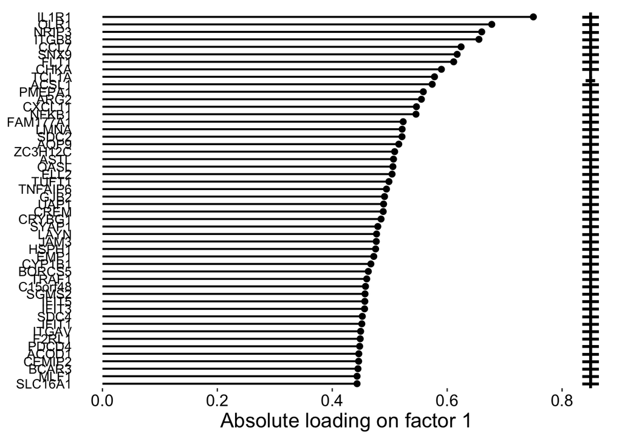

```r
plotTopWeights(
  MOFAobject,
  view="rnaseq",
  nfeatures=50,
  factor=1, scale= F
)
```

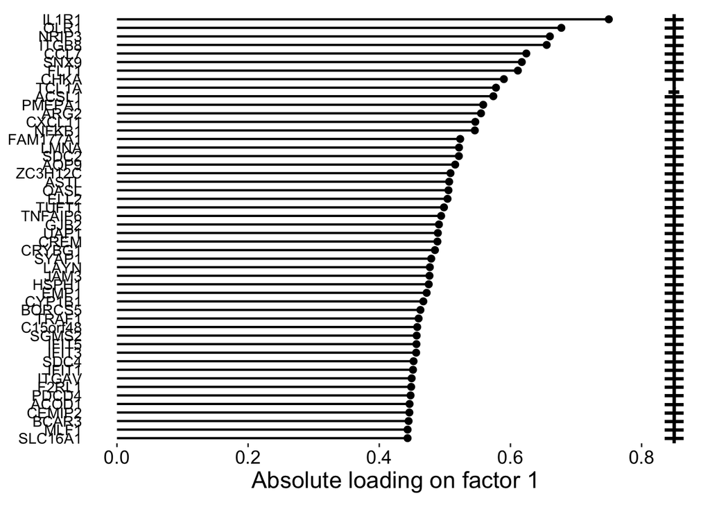

```r
plotTopWeights(
  MOFAobject,
  view="rnaseq",
  nfeatures=50,
  factor=1, scale= F
)
```

# PATHWAY ANALYSIS using blood transcriptional modules

```r
data("reactomeGS", package = "MOFAdata")
# binary matrix with feature sets in rows and features in columns

# perform enrichment analysis
gsea <- runEnrichmentAnalysis(
  MOFAobject,
  view = "rnaseq",
  feature.sets = BTM,
  alpha = 0.05
)
```

```
## Doing Feature Set Enrichment Analysis with the following options...
```

```
## View: rnaseq
```

```
## Factors: LF1 LF2 LF3 LF4 LF5 LF6 LF7
```

```
## Number of feature sets: 98
```

```
## Local statistic: loading
```

```
## Transformation: abs.value
```

```
## Global statistic: mean.diff
```

```
## Statistical test: parametric
```

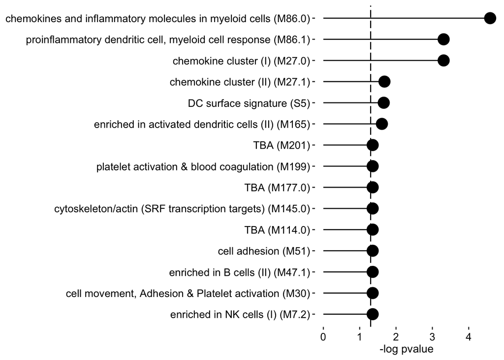

```r
interestingFactors <- 1:2

fseaplots <- lapply(interestingFactors, function(factor) {
  plotEnrichment(
    MOFAobject,
    gsea,
    factor = factor,
    alpha = 0.05,
    max.pathways = 15 # The top number of pathways to display
  )
})

fseaplots[[1]]
```

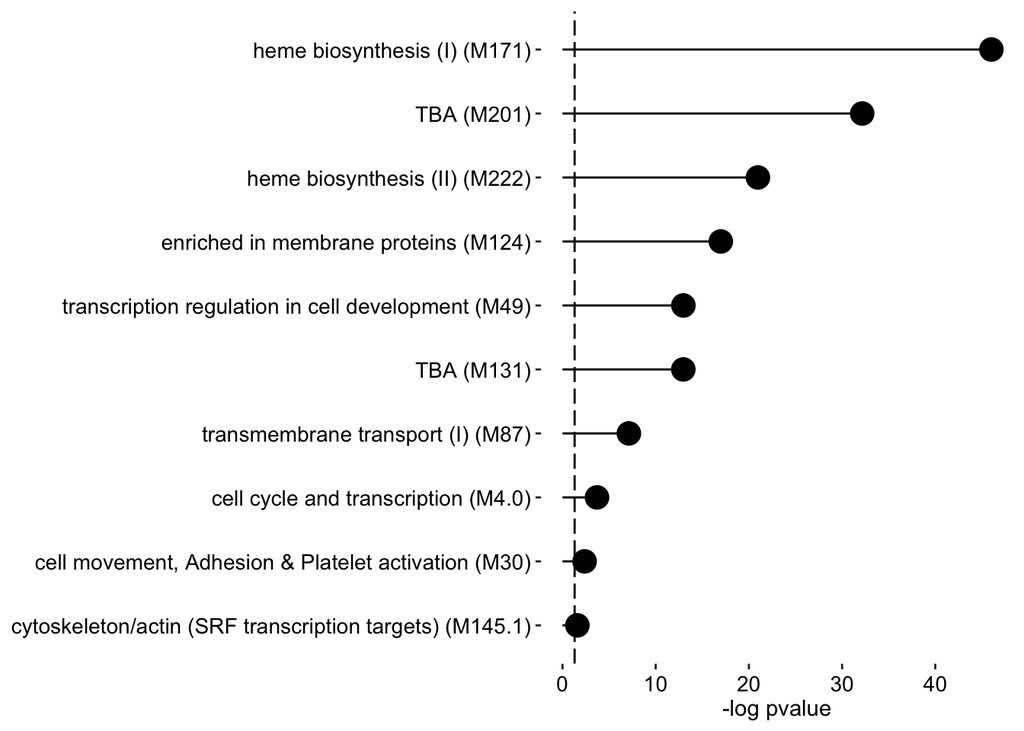

```r
fseaplots[[2]]
```

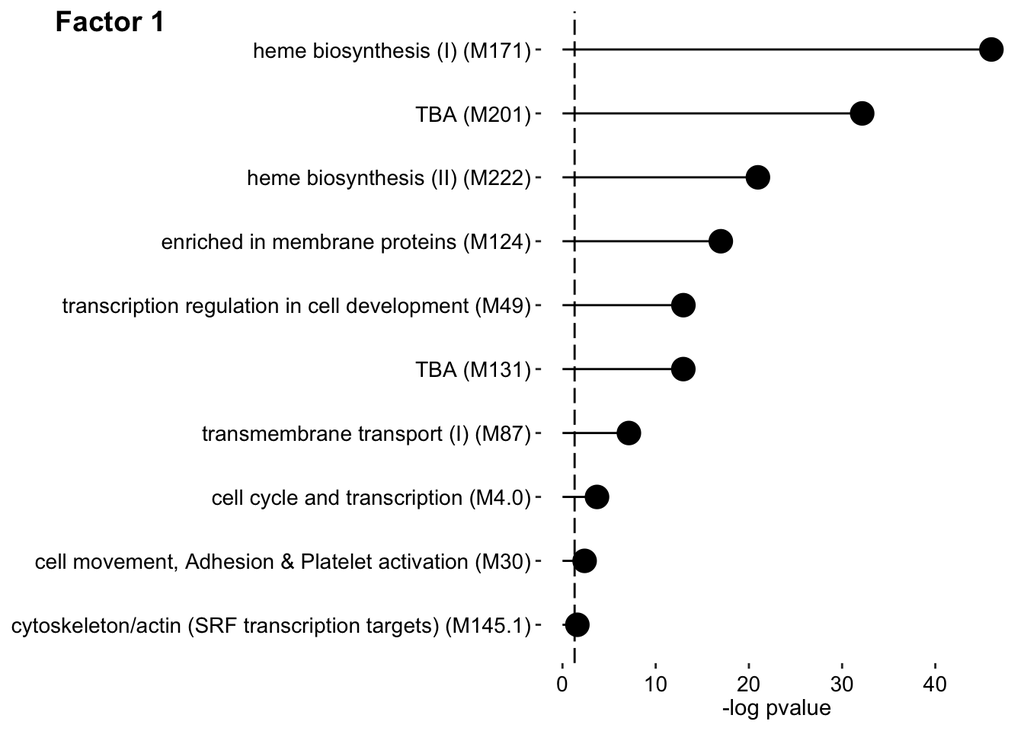

```r
cowplot::plot_grid(fseaplots[[2]],
                   ncol = 1, labels = paste("Factor", interestingFactors))
```